# Actividad 2 Ejercicio 1

CARIS ANDREA CHIA AMAYA - WEIMAR CORTES

2024-08-18

# EJERCICIO 1

Estimación del valor de π La siguiente figura sugiere como estimar el valor de π con una simulación. En la figura, un círcuito con un área igual a π/4, está inscrito en un cuadrado cuya área es igual a 1. Se elige de forma aleatoria n puntos dentro del cuadrado . La probabilidad de que un punto esté dentro del círculo es igual a la fracción del área del cuadrado que abarca a éste, la cual es π/4. Por tanto, se puede estimar el valor de π/4 al contar el número de puntos dentro del círculo, para obtener la estimación de π/4. De este último resultado se encontrar una aproximación para el valor de π.

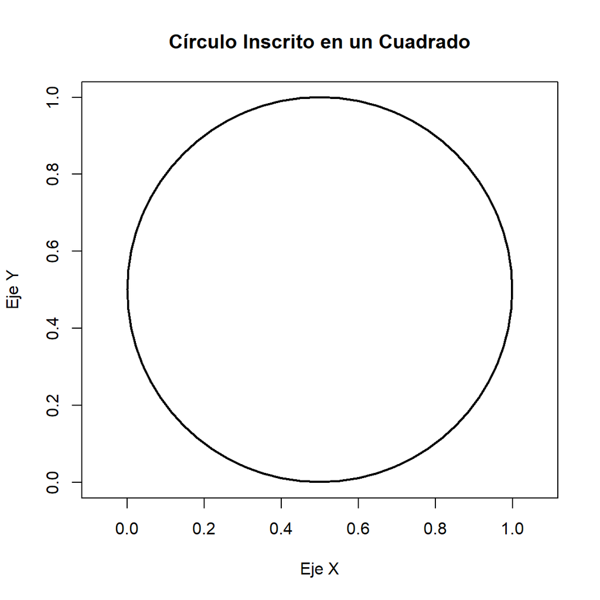

Figura

# ANÁLISIS

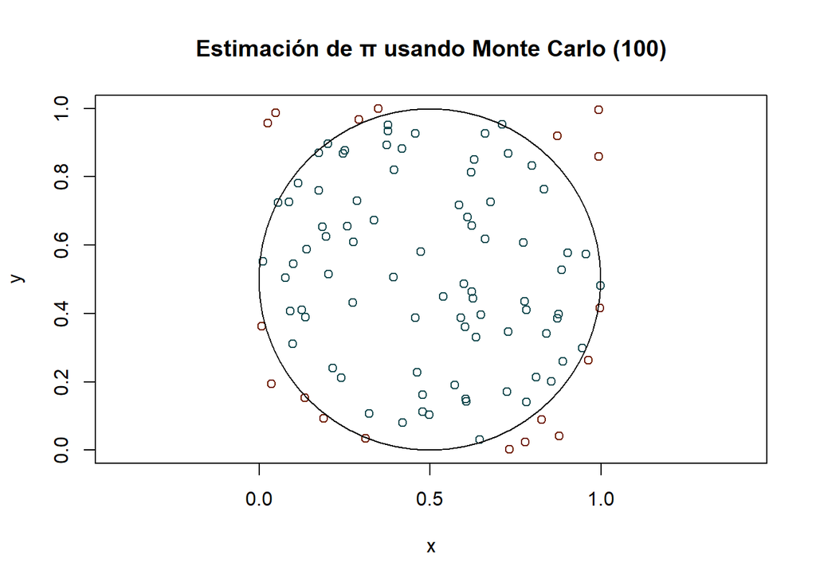

Resultados de la Estimación de π con 100 datos

| Puntos.Dentro.Circulo | Estimacion.de.Pi | Error.Absoluto | Error.Relativo |
| --- | --- | --- | --- |
| 82 | 3.28 | 0.138407 | 0.044056 |

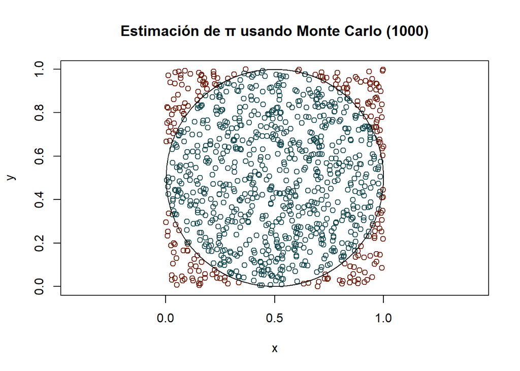

Resultados de la Estimación de π con 1000 datos

| Puntos.Dentro.Circulo | Estimacion.de.Pi | Error.Absoluto | Error.Relativo |
| --- | --- | --- | --- |
| 782 | 3.128 | 0.013593 | 0.004327 |

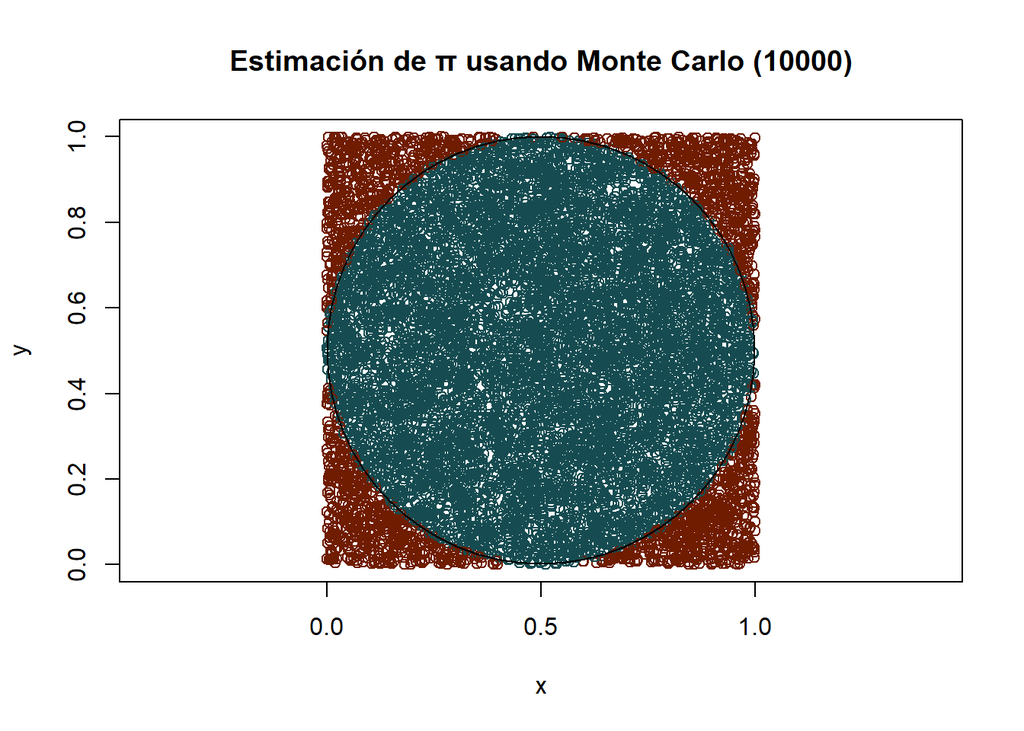

Resultados de la Estimación de π con 10.000 datos

| Puntos.Dentro.Circulo | Estimacion.de.Pi | Error.Absoluto | Error.Relativo |
| --- | --- | --- | --- |
| 7836 | 3.1344 | 0.007193 | 0.002289 |